# Project 3: Data Wrangling

## Udacity Data Analyst Nanodegree

### by Karma Dolma Gurung

# WeRateDogs Tweet Data Wrangling Project

[figure not shown]

IPython.display.Image

## What is Data Wrangling?

Data wrangling is the process of gathering, selecting and transforming data to answer an analytical question  
It is also known as data cleaning and also the step where 80% of the time is spent by analytics professional.(ref: www.elderresearch.com)

[figure not shown]

(Ref: Trifacta)

## For the purpose of this project:

- Gathering data  
- Assessing data  
- Cleaning data  
- Storing, analyzing, and visualizing your wrangled data  
- Reporting on 1) my data wrangling efforts and 2) my data analyses and visualizations

## Data Source 1: 'Twitter Archive' data

```python
df_csv.head()
```

|  | tweet_id | in_reply_to_status_id | in_reply_to_user_id | timestamp | source | text | retweeted_status_id | retweeted_status_user_id | retweeted_status_timestamp | expanded_urls | rating_numerator | rating_denominator | name | doggo | floofer | pupper | puppo |
| --- | --- | --- | --- | --- | --- | --- | --- | --- | --- | --- | --- | --- | --- | --- | --- | --- | --- |
| 0 | 892420643555336193 | NaN | NaN | 2017-08-01 16:23:56 +0000 | <a href="http://twitter.com/download/iphone" r... | This is Phineas. He's a mystical boy. Only eve... | NaN | NaN | NaN | https://twitter.com/dog_rates/status/892420643... | 13 | 10 | Phineas | None | None | None | None |
| 1 | 892177421306343426 | NaN | NaN | 2017-08-01 00:17:27 +0000 | <a href="http://twitter.com/download/iphone" r... | This is Tilly. She's just checking pup on you.... | NaN | NaN | NaN | https://twitter.com/dog_rates/status/892177421... | 13 | 10 | Tilly | None | None | None | None |
| 2 | 891815181378084864 | NaN | NaN | 2017-07-31 00:18:03 +0000 | <a href="http://twitter.com/download/iphone" r... | This is Archie. He is a rare Norwegian Pouncin... | NaN | NaN | NaN | https://twitter.com/dog_rates/status/891815181... | 12 | 10 | Archie | None | None | None | None |
| 3 | 891689557279858688 | NaN | NaN | 2017-07-30 15:58:51 +0000 | <a href="http://twitter.com/download/iphone" r... | This is Darla. She commenced a snooze mid meal... | NaN | NaN | NaN | https://twitter.com/dog_rates/status/891689557... | 13 | 10 | Darla | None | None | None | None |
| 4 | 891327558926688256 | NaN | NaN | 2017-07-29 16:00:24 +0000 | <a href="http://twitter.com/download/iphone" r... | This is Franklin. He would like you to stop ca... | NaN | NaN | NaN | https://twitter.com/dog_rates/status/891327558... | 12 | 10 | Franklin | None | None | None | None |

## Data Source 2: 'Image Predictions' file

```python
#Parsing the concatenated column
df_tsv = pd.read_csv("image-predictions.tsv",sep="\t",header=0)
df_tsv.head()
```

|  | tweet_id | jpg_url | img_num | p1 | p1_conf | p1_dog | p2 | p2_conf | p2_dog | p3 | p3_conf | p3_dog |
| --- | --- | --- | --- | --- | --- | --- | --- | --- | --- | --- | --- | --- |
| 0 | 666020888022790149 | https://pbs.twimg.com/media/CT4udn0WwAA0aMy.jpg | 1 | Welsh_springer_spaniel | 0.465074 | True | collie | 0.156665 | True | Shetland_sheepdog | 0.061428 | True |
| 1 | 666029285002620928 | https://pbs.twimg.com/media/CT42GRgUYAA5iDo.jpg | 1 | redbone | 0.506826 | True | miniature_pinscher | 0.074192 | True | Rhodesian_ridgeback | 0.072010 | True |
| 2 | 666033412701032449 | https://pbs.twimg.com/media/CT4521TWwAEvMyu.jpg | 1 | German_shepherd | 0.596461 | True | malinois | 0.138584 | True | bloodhound | 0.116197 | True |
| 3 | 666044226329800704 | https://pbs.twimg.com/media/CT5Dr8HUEAA-lEu.jpg | 1 | Rhodesian_ridgeback | 0.408143 | True | redbone | 0.360687 | True | miniature_pinscher | 0.222752 | True |
| 4 | 666049248165822465 | https://pbs.twimg.com/media/CT5IQmsXIAAKY4A.jpg | 1 | miniature_pinscher | 0.560311 | True | Rottweiler | 0.243682 | True | Doberman | 0.154629 | True |

## Data Source 3: Twitter API

```python
tweet_data =[]
with open('tweet-json.txt', 'r') as file:
    for line in file:
        data = json.loads(line)
        tweet_data.append({'tweet_id' : data['id'], 'retweet_count' : data['retweet_count'],
                           'favorite_count' : data['favorite_count'], 'retweeted' : data['retweeted'],
                           'full_text' : data['full_text']})

df_tweets = pd.DataFrame(tweet_data, columns=['tweet_id', 'retweet_count', 'favorite_count', 'retweeted', 'full_text'])
df_tweets
```

|  | tweet_id | retweet_count | favorite_count | retweeted | full_text |
| --- | --- | --- | --- | --- | --- |
| 0 | 892420643555336193 | 8853 | 39467 | False | This is Phineas. He's a mystical boy. Only eve... |
| 1 | 892177421306343426 | 6514 | 33819 | False | This is Tilly. She's just checking pup on you.... |
| 2 | 891815181378084864 | 4328 | 25461 | False | This is Archie. He is a rare Norwegian Pouncin... |
| 3 | 891689557279858688 | 8964 | 42908 | False | This is Darla. She commenced a snooze mid meal... |
| 4 | 891327558926688256 | 9774 | 41048 | False | This is Franklin. He would like you to stop ca... |
| ... | ... | ... | ... | ... | ... |
| 2349 | 666049248165822465 | 41 | 111 | False | Here we have a 1949 1st generation vulpix. Enj... |
| 2350 | 666044226329800704 | 147 | 311 | False | This is a purebred Piers Morgan. Loves to Netf... |
| 2351 | 666033412701032449 | 47 | 128 | False | Here is a very happy pup. Big fan of well-main... |
| 2352 | 666029285002620928 | 48 | 132 | False | This is a western brown Mitsubishi terrier. Up... |
| 2353 | 666020888022790149 | 532 | 2535 | False | Here we have a Japanese Irish Setter. Lost eye... |

2354 rows × 5 columns

## Assessing data

The goal of this steps is to identify any quality and tidiness issues. Assessment of data is done in two steps:  
1) First is the visual assesssment where you eyeball the tables.  
2) Second is the programmatic assessment where you use several functions such as info(), describer(), shape and so on.

A good principle is to document the issues identified as you go about assessing the data.

## Quality

Quality mainly refers to the content issues. Four of the main quality dimensions are:  
1) Completeness: do we have all of the records that we should? Do we have missing records or not? Are there specific rows, columns, or cells missing?  
2) Validity: Records that do not conform to the rules of data For example: negative height is impossible and also unique key constraints in tables).  
3) Accuracy: Inaccurate data is wrong data that is valid. It adheres to the defined schema, but it is still incorrect. Example: a patient's weight that is 5 lbs too heavy because the scale was faulty.  
4) Consistency: Consistency refers to the format of representing the data. For example: Newyork can be represented as "NEWYORK" or "NY".

## Tidiness

Tidiness mainly refers to the structural issues of the data.

For instance in the table below, Drug A, Drug B and Drug C can be transformed into two tables. One to specify the drug "Drug Type" and the second to specify the dosage "Dosage".

[figure not shown]

## Examples of Programmatic Assessment

```python
df_csv_copy.info()
```

```
<class 'pandas.core.frame.DataFrame'>
RangeIndex: 2356 entries, 0 to 2355
Data columns (total 17 columns):
 #   Column                      Non-Null Count  Dtype
---  ------                      --------------  -----
 0   tweet_id                    2356 non-null   int64
 1   in_reply_to_status_id       78 non-null     float64
 2   in_reply_to_user_id         78 non-null     float64
 3   timestamp                   2356 non-null   object
 4   source                      2356 non-null   object
 5   text                        2356 non-null   object
 6   retweeted_status_id         181 non-null    float64
 7   retweeted_status_user_id    181 non-null    float64
 8   retweeted_status_timestamp  181 non-null    object
 9   expanded_urls               2297 non-null   object
 10  rating_numerator            2356 non-null   int64
 11  rating_denominator          2356 non-null   int64
 12  name                        2356 non-null   object
 13  doggo                       2356 non-null   object
 14  floofer                     2356 non-null   object
 15  pupper                      2356 non-null   object
 16  puppo                       2356 non-null   object
dtypes: float64(4), int64(3), object(10)
memory usage: 313.0+ KB
```

```python
df_csv_copy.describe()
```

|  | tweet_id | in_reply_to_status_id | in_reply_to_user_id | retweeted_status_id | retweeted_status_user_id | rating_numerator | rating_denominator |
| --- | --- | --- | --- | --- | --- | --- | --- |
| count | 2.356000e+03 | 7.800000e+01 | 7.800000e+01 | 1.810000e+02 | 1.810000e+02 | 2356.000000 | 2356.000000 |
| mean | 7.427716e+17 | 7.455079e+17 | 2.014171e+16 | 7.720400e+17 | 1.241698e+16 | 13.126486 | 10.455433 |
| std | 6.856705e+16 | 7.582492e+16 | 1.252797e+17 | 6.236928e+16 | 9.599254e+16 | 45.876648 | 6.745237 |
| min | 6.660209e+17 | 6.658147e+17 | 1.185634e+07 | 6.661041e+17 | 7.832140e+05 | 0.000000 | 0.000000 |
| 25% | 6.783989e+17 | 6.757419e+17 | 3.086374e+08 | 7.186315e+17 | 4.196984e+09 | 10.000000 | 10.000000 |
| 50% | 7.196279e+17 | 7.038708e+17 | 4.196984e+09 | 7.804657e+17 | 4.196984e+09 | 11.000000 | 10.000000 |
| 75% | 7.993373e+17 | 8.257804e+17 | 4.196984e+09 | 8.203146e+17 | 4.196984e+09 | 12.000000 | 10.000000 |
| max | 8.924206e+17 | 8.862664e+17 | 8.405479e+17 | 8.874740e+17 | 7.874618e+17 | 1776.000000 | 170.000000 |

```python
df_csv_copy['name'].value_counts()
```

```
None       745
a           55
Charlie     12
Lucy        11
Oliver      11
          ...
Yoda         1
Crumpet      1
Jaspers      1
Eugene       1
old          1
Name: name, Length: 957, dtype: int64
```

```python
df_csv_copy.isnull().count()
```

```
tweet_id                      2356
in_reply_to_status_id         2356
in_reply_to_user_id           2356
timestamp                     2356
source                        2356
text                          2356
retweeted_status_id           2356
retweeted_status_user_id      2356
retweeted_status_timestamp    2356
expanded_urls                 2356
rating_numerator              2356
rating_denominator            2356
name                          2356
doggo                         2356
floofer                       2356
pupper                        2356
puppo                         2356
dtype: int64
```

```python
df_csv_copy[df_csv_copy.tweet_id.duplicated()]
```

|  | tweet_id | in_reply_to_status_id | in_reply_to_user_id | timestamp | source | text | retweeted_status_id | retweeted_status_user_id | retweeted_status_timestamp | expanded_urls | rating_numerator | rating_denominator | name | doggo | floofer | pupper | puppo |
| --- | --- | --- | --- | --- | --- | --- | --- | --- | --- | --- | --- | --- | --- | --- | --- | --- | --- |

```python
df_tsv_copy.shape
```

```
(2075, 12)
```

```python
df_tsv_copy.tail()
```

|  | tweet_id | jpg_url | img_num | p1 | p1_conf | p1_dog | p2 | p2_conf | p2_dog | p3 | p3_conf | p3_dog |
| --- | --- | --- | --- | --- | --- | --- | --- | --- | --- | --- | --- | --- |
| 2070 | 891327558926688256 | https://pbs.twimg.com/media/DF6hr6BUMAAzZgT.jpg | 2 | basset | 0.555712 | True | English_springer | 0.225770 | True | German_short-haired_pointer | 0.175219 | True |
| 2071 | 891689557279858688 | https://pbs.twimg.com/media/DF_q7IAWsAEuuN8.jpg | 1 | paper_towel | 0.170278 | False | Labrador_retriever | 0.168086 | True | spatula | 0.040836 | False |
| 2072 | 891815181378084864 | https://pbs.twimg.com/media/DGBdLU1WsAANxJ9.jpg | 1 | Chihuahua | 0.716012 | True | malamute | 0.078253 | True | kelpie | 0.031379 | True |
| 2073 | 892177421306343426 | https://pbs.twimg.com/media/DGGmoV4XsAAUL6n.jpg | 1 | Chihuahua | 0.323581 | True | Pekinese | 0.090647 | True | papillon | 0.068957 | True |
| 2074 | 892420643555336193 | https://pbs.twimg.com/media/DGKD1-bXoAAIAUK.jpg | 1 | orange | 0.097049 | False | bagel | 0.085851 | False | banana | 0.076110 | False |

```python
df_tsv_copy.sample(3)
```

|  | tweet_id | jpg_url | img_num | p1 | p1_conf | p1_dog | p2 | p2_conf | p2_dog | p3 | p3_conf | p3_dog |
| --- | --- | --- | --- | --- | --- | --- | --- | --- | --- | --- | --- | --- |
| 977 | 707038192327901184 | https://pbs.twimg.com/media/Cc_ney1W4AANuY3.jpg | 1 | pug | 0.642426 | True | llama | 0.057306 | False | French_bulldog | 0.054186 | True |
| 1844 | 838916489579200512 | https://pbs.twimg.com/media/C6RkiQZUsAAM4R4.jpg | 2 | web_site | 0.993651 | False | monitor | 0.001406 | False | envelope | 0.001093 | False |
| 182 | 669351434509529089 | https://pbs.twimg.com/media/CUoDk8mWsAAMyBL.jpg | 1 | cuirass | 0.756829 | False | breastplate | 0.233520 | False | bulletproof_vest | 0.003812 | False |

## Quality

#### df_csv

- Quality: The url links appear duplicated in the column "expanded_urls" and few of the urls contain link to other than twitter.
- Quality: Replace rows with names as "a" with "None"
- Quality: Datatype for "timestamp" and "retweeted_status_timestamp" is an object instead of datetime.
- Quality: Replacing the values "None" in the columns "doggo", "floofer", "pupper" and "puppo" to "".
- Tidiness: Not visibile in the notebook but visually assessing the data in the spreadsheet shows that the "text" column has the url link to the tweet.

#### df_tsv

- No qualtiy or tidiness issues were observed.

#### df_tweets

- Quality: All the records with the "retweet_count" have "retweeted" as False. If the records have retweeted_count, they will be replace with True.
- Tidiness: Dataframes df_csv and df_tweets will be merged since they have similar number of records.

## Cleaning data

#### Define

There are more than 1 same Twitter links and some of the links are to sites other than Twitter. Extracting the first instance of the link to twitter from 'expanded_urls'.

```python
df_csv_copy['expanded_urls'][6]
```

```
'https://gofundme.com/ydvmve-surgery-for-jax,https://twitter.com/dog_rates/status/890971913173991426/photo/1'
```

#### Code

```python
reg = "(?P<url>https:\/\/twitter.com?\/[^\s]+?\/1)"
df_csv_copy['expanded_urls'] = df_csv_copy['expanded_urls'].str.findall(reg)
```

#### Test

```python
#Testing if the above extraction worked
df_csv_copy['expanded_urls'][6]
```

```
['https://twitter.com/dog_rates/status/890971913173991426/photo/1']
```

## Analysing

### Exploratory Analysis

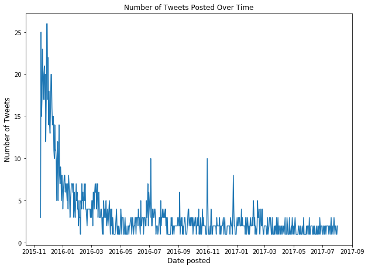

```python
#Plotting line chart for date posted
plt.figure(figsize=[ 10, 7.27])
df_concat.groupby('date_posted').tweet_id.nunique().plot()
plt.xlabel('Date posted',fontsize=12)
plt.ylabel('Number of Tweets',fontsize=12)
plt.title('Number of Tweets Posted Over Time',fontsize=12)
plt.savefig('Number of Tweets Poster Over Time');
```

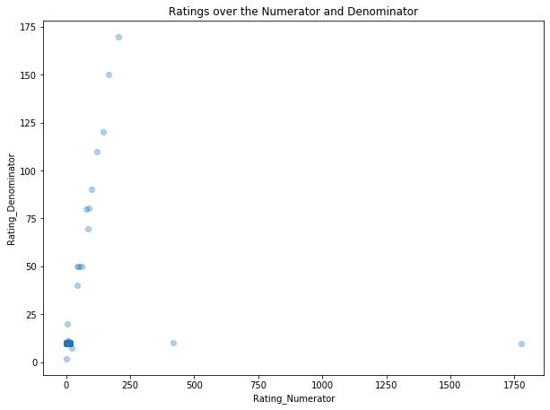

```python
#Plotting scatterplots to check outliers
plt.figure(figsize=[10, 7.27])
sb.regplot(data = df_concat, x = 'rating_numerator', y = 'rating_denominator', fit_reg = False,
           x_jitter = 0.2, y_jitter = 0.2, scatter_kws = {'alpha' : 1/3})
plt.title('Ratings over the Numerator and Denominator')
plt.xlabel('Rating_Numerator')
plt.ylabel('Rating_Denominator')
plt.savefig('Ratings over the Numerator and Denominator');
```

This scatter plot gives a nice overview of the outliers of the ratings. This can be important to detect as they can distort the analysis and should be removed if necessary.

## We have finally come to the end of the presentation. Any questions?